# PSTAT 120C HW 1

TJ Sipin

2022-08-10

# Reading

### Define deterministic and probabilistic mathematical models. Give an example of each.

A deterministic model does not have an error component when predicting a response variable $y$ as a function of a set of explanatory variables. On the other hand, a probabilistic model is one that has an error component $\epsilon$, such that it produces a random variable $Y$. It must be noted that a probabilistic model can be interpreted as a sum of a deterministic component $\mathbb E(Y)$ and a random component $\epsilon$.

An example of a deterministic model:

$$y = 2x + 3$$

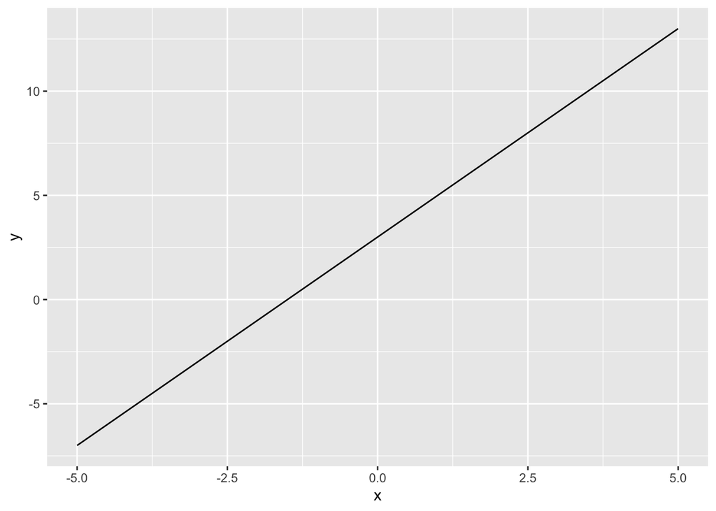

```r
x = seq(-5, 5, by = 0.1)
y = 2*x + 3

ggplot() +
  geom_line(aes(x = x,
                y = y))
```

An example of a probabilistic model:

$$Y = 3 + 2x + \epsilon, \qquad \epsilon \sim N(0,1)$$

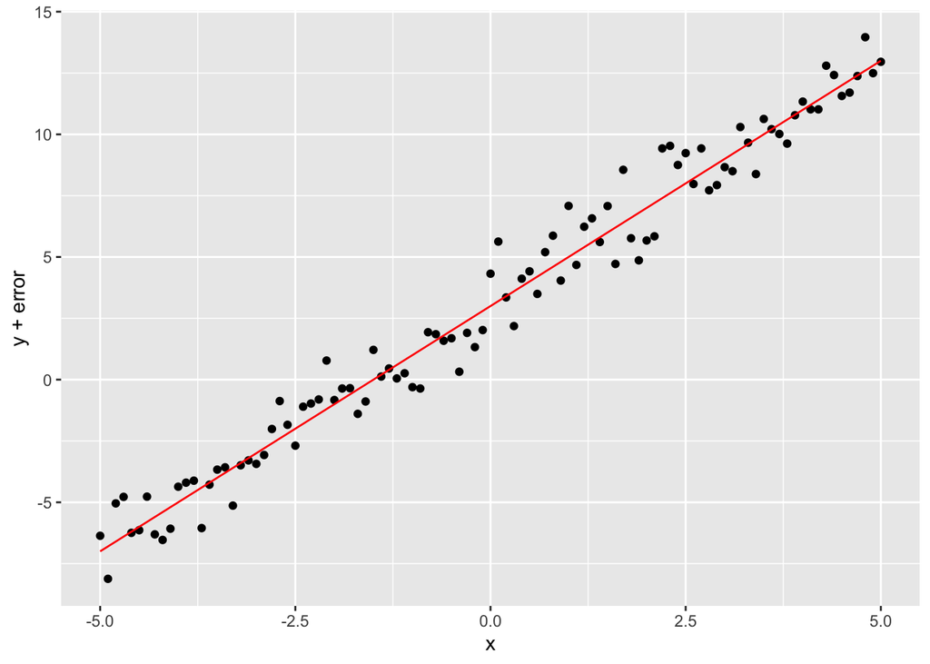

```r
error = rnorm(n = length(x), mean = 0, sd = 1)

ggplot() +
  geom_point(aes(x = x,
                 y = y + error)) +
  geom_line(aes(x = x,
                y = y),
            col = 'red')
```

### Write the general equation for a simple linear regression model.

The general equation:

$$y = \beta_0 + \beta_1 x + \epsilon$$

### Describe, in your own words, the overall concept of the method of least squares.

The idea is to find a set of parameter estimates $\beta_i, \quad i = 0,\dots, n$, where $n = 1$ for the simple linear regression model case, such that the error $y_i - \hat y_i$ is minimized. In other words, we want to minimize $SSE = \displaystyle \sum _{i = 1} ^n(y_i - \hat y_i ) ^2.$

### State the least-squares estimators for the simple linear regression model.

Derived from the lecture demonstration, the OLS estimators for the simple linear regression model are

$$\begin{align}
\hat\beta_0 &= \bar y - \hat\beta_1\bar x \\
\hat\beta_1 &= \frac{\displaystyle \sum_{i = 1}^{n}(x_i - \bar
x)(y_i - \bar y)}{\displaystyle \sum_{i = 1}^{n}(x_i - \bar x)^2}
\end{align}$$
### State the means and variances of the least-squares estimators in simple linear regression.

#### Means

Since the estimators $\hat\beta_0, \hat\beta_1$ are unbiased, then
$$\begin{aligned}
\mathbb E(\hat\beta_0) &= \beta_0 \\
\mathbb E(\hat\beta_1) &= \beta_1
\end{aligned}$$

#### Variances

$$\begin{align}
\text{var}(\hat\beta_0) &= \frac{\sigma^2}{nS_{xx}}\sum x_i^2 \\
\text{var}(\hat\beta_1) &= \frac{\sigma^2}{S_{xx}}
\end{align}$$

### State a pair of null and alternative hypotheses for making inferences about single regression parameters and linear functions of the parameters.

Testing for $\theta = a_o \beta_0 + a_1\beta_1$

$$\begin{aligned}
H_0 &: \theta = \theta_0 \\
H_a &:
\begin{cases}
\theta > \theta_0 \\
\theta < \theta_0 \\
\theta \neq \theta_0
\end{cases}
\end{aligned}$$

# Practice

1. Auditors are often required to compare the audited (or current) value of an inventory item with the book (or listed) value. If a company is keeping its inventory and books up to date, there should be a strong linear relationship between the audited and book values. A company sampled ten inventory items and obtained the audited and book values given in the accompanying code.
1. Fit the model $Y = \beta_0 + \beta_1 x + \epsilon$ to the data, using least squares.

```r
audit <- c(9,14,7,29,45,
           109,40,238,60,170)
book <- c(10,12,9,27,47,
          112,36,241,59,167)
audit_df <- data.frame(audit = audit,
                       book = book)

lm_audit <- lm(audit ~ book, data = audit_df)

lm_audit %>% summary
```

```
##
## Call:
## lm(formula = audit ~ book, data = audit_df)
##
## Residuals:
##     Min      1Q  Median      3Q     Max
## -2.7557 -2.1477 -0.4228  1.4803  3.7178
##
## Coefficients:
##             Estimate Std. Error t value Pr(>|t|)
## (Intercept)   0.7198     1.1764   0.612    0.558
## book          0.9914     0.0114  86.994  3.4e-13 ***
## ---
## Signif. codes:  0 '***' 0.001 '**' 0.01 '*' 0.05 '.' 0.1 ' ' 1
##
## Residual standard error: 2.666 on 8 degrees of freedom
## Multiple R-squared:  0.9989, Adjusted R-squared:  0.9988
## F-statistic:  7568 on 1 and 8 DF,  p-value: 3.401e-13
```

2. Plot the 10 data points and graph the line representing the model.

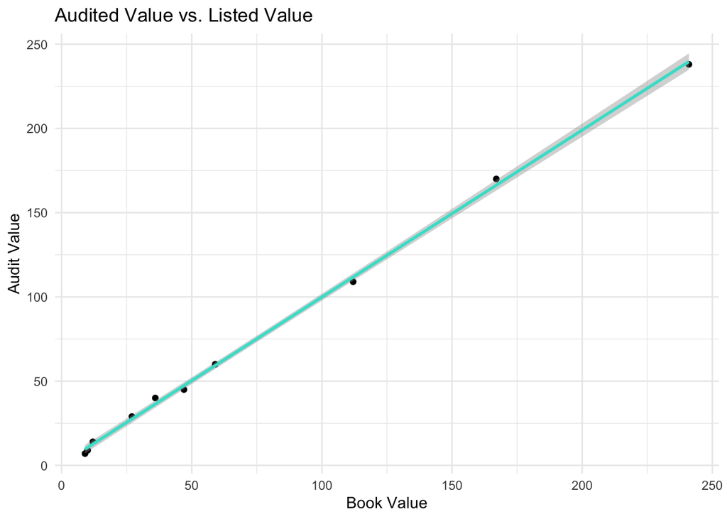

```r
ggplot(data = audit_df,
       aes(x = book,
             y = audit)) +
  geom_point() +
  geom_smooth(method = 'lm',
              color = 'turquoise') +
  theme_minimal() +
  labs(x = 'Book Value',
       y = 'Audit Value') +
  ggtitle('Audited Value vs. Listed Value')
```

3. Calculate $SSE$ and $S^2$

```r
sse = sum(lm_audit$residuals^2)
sse
```

```
## [1] 56.84544
```

```r
var(lm_audit$residuals) # sse/(n-1), n = 10
```

```
## [1] 6.31616
```

4. Do the data present sufficient evidence to indicate that the slope $\beta_1$ differs from zero? Conduct a hypothesis test at the 5% significance level.

The p-value for $\beta_1$ is $3.401 \times 10^{-13}$, which is much smaller than $0.05$, thus the data presents sufficient evidence to indicate that the slope differs from zero at a 5% significance level.

5. What is the model’s estimate from the expected change in audited value per one-unit change in book value?

There is about a one-unit ($0.9914$) change in audited value per one-unit change in book value.

6. What does the model predict the audited value to be for an item with a book value of $100?

$$\begin{aligned}
y &= 0.7198 + 0.9914(100) \\
&= 99.8598
\end{aligned}$$

2. Let $\beta_0$ and $\beta_1$ be the least-squares estimates for the intercept and slope in a simple linear regression model. Show that the least-squares equation $\hat y = \hat\beta_0 + \hat\beta_1 x$ will always go through the point $(\bar x, \bar y).$

Since

$$\begin {aligned}
\hat\beta_0 &= \bar y - \hat\beta_1 \bar x \\
\hat\beta_1 &= \frac{\sum_{i=1}^{n}(x_i - \bar x)(y_i - \bar
y)}{\sum_{i=1}^{n}(x_i - \bar x)^2}
\end {aligned}$$

then we have

$$\begin{align}
\hat y &= \bar y - \hat\beta_1 \bar x + \frac{\sum_{i=1}^{n}(x_i -
\bar x)(y_i - \bar y)}{\sum_{i=1}^{n}(x_i - \bar x)^2} x \\
&= \bar y - \frac{\sum_{i=1}^{n}(x_i - \bar x)(y_i - \bar
y)}{\sum_{i=1}^{n}(x_i - \bar x)^2} \bar x + \frac{\sum_{i=1}^{n}(x_i -
\bar x)(y_i - \bar y)}{\sum_{i=1}^{n}(x_i - \bar x)^2} x
\end{align}$$

To show that this line always goes through the point $(\bar x, \bar y)$, then we substitute $\bar x$ for $x$ and $\bar y$ for $\hat y$.

$$\begin{aligned}
\bar y &= \bar y - \frac{\sum_{i=1}^{n}(x_i - \bar x)(y_i - \bar
y)}{\sum_{i=1}^{n}(x_i - \bar x)^2} \bar x + \frac{\sum_{i=1}^{n}(x_i -
\bar x)(y_i - \bar y)}{\sum_{i=1}^{n}(x_i - \bar x)^2} \bar x \\
&= \bar y
\end{aligned}$$

We see that the left- and right-hand sides of the equation are indeed equal with this substitution, so the equation $\hat y = \hat\beta_0 + \hat\beta_1 x$ will always go through the point $(\hat x, \hat y)$.

Another approach would be
$$\begin{align}
\bar y &= \frac{1}{n}\sum_{i=1}^{n} y_i \\
&= \frac{1}{n}\sum_{i=1}^{n} (\hat y_i + \epsilon_i) \\
&= \frac{1}{n}\sum_{i=1}^{n} (\hat\beta_0 + \hat\beta_1 x_i +
\epsilon_i) \\
&= \frac{1}{n}\sum_{i=1}^{n} (\hat\beta_0 + \hat\beta_1 x_i) \tag 1
\\
&= \frac{1}{n}\sum_{i=1}^{n} (\beta_0 + \beta_1 x_i) \\
&= \frac{1}{n}\sum_{i=1}^{n} (\beta_0) + \sum_{i=1}^{n}(\beta_1 x_i)
\\
&= \frac{1}{n} n\beta_0 + \frac{1}{n}n\beta_1 \sum_{i=1}^{n} x_i \\
&= \beta_0 + \beta_1 \bar x \\
\implies \bar y &= \beta_0 + \beta_1 \bar x
\end{align}$$

The $\epsilon_i$ disappears in $(1)$ because of the assumption that $\mathbb E(\mathbf \epsilon) = 0$. Since $\bar y = \beta_0 + \beta_1 \hat x$ is of the same form as $\hat y = \hat \beta_0 + \hat \beta_1 x = \beta_0 + \beta_1 x$, then we can conclude that the equation always goes through $(\bar x, \bar y).$

3. Suppose that the model $y = \beta_0 + \beta_1 x + \epsilon$ is fit to the $n$ data points $(y_1,x_1),\dots,(y_n,x_n)$. At what value of $x$ will the length of the prediction interval for $y$ be minimized?

The length of a prediction interval for an actual value of $Y$ when $x = x^*$ is given by the equation

$$2 \times t_{\alpha/2}S \displaystyle \sqrt{1 + \frac{1}{n} + \frac{(x^*
- \bar x)^2}{S_{xx}}}.$$

So what we want is the choice of $x^*$ that minimizes this equation. In other words,

$$\min \arg_{x^*} 2 \times t_{\alpha/2}S \displaystyle \sqrt{1 +
\frac{1}{n} + \frac{(x^* - \bar x)^2}{S_{xx}}}.$$

The choice of $x^*$ that minimizes the length of the prediction interval is $\bar x$.

```r
knitr::opts_chunk$set(echo = TRUE)
library(ggplot2)
library(tidymodels)
x = seq(-5, 5, by = 0.1)
y = 2*x + 3

ggplot() +
  geom_line(aes(x = x,
                y = y))
error = rnorm(n = length(x), mean = 0, sd = 1)

ggplot() +
  geom_point(aes(x = x,
                 y = y + error)) +
  geom_line(aes(x = x,
                y = y),
            col = 'red')

audit <- c(9,14,7,29,45,
           109,40,238,60,170)
book <- c(10,12,9,27,47,
          112,36,241,59,167)
audit_df <- data.frame(audit = audit,
                       book = book)

lm_audit <- lm(audit ~ book, data = audit_df)

lm_audit %>% summary
ggplot(data = audit_df,
       aes(x = book,
             y = audit)) +
  geom_point() +
  geom_smooth(method = 'lm',
              color = 'turquoise') +
  theme_minimal() +
  labs(x = 'Book Value',
       y = 'Audit Value') +
  ggtitle('Audited Value vs. Listed Value')
sse = sum(lm_audit$residuals^2)
sse

var(lm_audit$residuals) # sse/(n-1), n = 10
```